# 1. Reaction networks, stoichiometry, and epidemic dynamics

Phylodynamics.jl vignettes

Author

Simon D. W. Frost

Published

October 28, 2026

## Overview

In structured phylodynamics, the genealogy of a pathogen sample is shaped by four classes of epidemiological reactions:

1. **Transmission (birth) reactions** $F_{kl}(t)$, where an infected individual in deme $k$ transmits to a susceptible host in deme $l$, increasing the total number of infected individuals by $+1$.
2. **Migration (stage-transition) reactions** $G_{kl}(t)$ ($k \ne l$), where an infected individual moves from deme $k$ to deme $l$, leaving the total number of infected individuals unchanged ($0$).
3. **Removal (recovery/mortality) reactions** $D_k(t)$, where an infected individual leaves deme $k$, decreasing the total number of infected individuals by $-1$.
4. **Demographic turnover** in uninfected compartments, which alters susceptible availability without directly creating or removing pathogen lineages.

Rather than requiring bespoke YAML files or hand-coded string rate expressions, `Phylodynamics.jl` works directly with reaction systems defined in `ModelingToolkit.jl` and `Catalyst.jl`. Given a `ReactionSystem` and a list of infected species `[Y1, Y2, ...]`, `classify_phylodynamic_reactions` inspects the substrate and product stoichiometry of each reaction to partition the network automatically into `:transmission`, `:migration`, `:removal`, and `:demographic` processes.

## Defining the two-host zoonosis reaction network

We consider a two-host SIRS model with an animal reservoir (susceptible $X_1$, infected $Y_1$) and a target human population (susceptible $X_2$, infected $Y_2$). Using `ModelingToolkit.jl` / `Catalyst.jl` syntax:

```julia
using Phylodynamics
using ModelingToolkit
using Catalyst
using Symbolics
using OrdinaryDiffEqTsit5
using JumpProcesses
using CairoMakie
using DataFrames
using StableRNGs

t = ModelingToolkit.t_nounits
@parameters nu1 mu1 gamma1 m1 beta nu2 mu2 gamma2 m2 epsilon phi psi
@species X1(t) Y1(t) X2(t) Y2(t)

rxs = [
    # 1. Reservoir demographic turnover
    Reaction(nu1, nothing, [X1], nothing, [1]),
    Reaction(mu1, [X1], nothing, [1], nothing),
    # 2. Reservoir-to-reservoir transmission (1 -> 1): X1 + Y1 --> 2Y1
    Reaction(beta, [X1, Y1], [Y1], [1, 1], [2]),
    # 3. Reservoir recovery & mortality: Y1 --> 0
    Reaction(gamma1, [Y1], nothing, [1], nothing),
    Reaction(mu1 + m1, [Y1], nothing, [1], nothing),
    # 4. Human demographic turnover
    Reaction(nu2, nothing, [X2], nothing, [1]),
    Reaction(mu2, [X2], nothing, [1], nothing),
    # 5. Zoonotic spillover (1 -> 2): X2 + Y1 --> Y2 + Y1
    Reaction(epsilon * beta, [X2, Y1], [Y2, Y1], [1, 1], [1, 1]),
    # 6. Human-to-human transmission (2 -> 2): X2 + Y2 --> 2Y2
    Reaction(phi * beta, [X2, Y2], [Y2], [1, 1], [2]),
    # 7. Reverse zoonosis / zooanthroponosis (2 -> 1): X1 + Y2 --> Y1 + Y2
    Reaction(psi * beta, [X1, Y2], [Y1, Y2], [1, 1], [1, 1]),
    # 8. Human recovery & mortality: Y2 --> 0
    Reaction(gamma2, [Y2], nothing, [1], nothing),
    Reaction(mu2 + m2, [Y2], nothing, [1], nothing)
]

@named zoonosis_rs = ReactionSystem(
    rxs, t, [X1, Y1, X2, Y2],
    [nu1, mu1, gamma1, m1, beta, nu2, mu2, gamma2, m2, epsilon, phi, psi];
    combinatoric_ratelaws = false
)
zoonosis_rs = complete(zoonosis_rs)
```

```
Model zoonosis_rs:
Unknowns (4): see unknowns(zoonosis_rs)
  X1(t)
  Y1(t)
  X2(t)
  Y2(t)
Parameters (12): see parameters(zoonosis_rs)
  nu1
  mu1
  gamma1
  m1
  ⋮
```

Equivalently, the same model can be written using the `Catalyst.@reaction_network` macro via `build_zoonosis_catalyst_network()`.

## Automatic stoichiometric reaction classification

Passing `zoonosis_rs` and the ordered vector of infected species `[Y1, Y2]` to `classify_phylodynamic_reactions` extracts the phylodynamic role and parent/child demes of every reaction directly from its stoichiometry:

```julia
specs = classify_phylodynamic_reactions(zoonosis_rs, [Y1, Y2])
DataFrame(
    index = [s.rx_index for s in specs],
    role = [s.role for s in specs],
    parent_deme = [s.parent_deme for s in specs],
    child_deme = [s.child_deme for s in specs],
    rate = [string(s.rx.rate) for s in specs]
)
```

12×5 DataFrame

| Row | index Int64 | role Symbol | parent_deme Int64 | child_deme Int64 | rate String |
| --- | --- | --- | --- | --- | --- |
| 1 | 1 | demographic | 0 | 0 | nu1 |
| 2 | 2 | demographic | 0 | 0 | mu1 |
| 3 | 3 | transmission | 1 | 1 | beta |
| 4 | 4 | removal | 1 | 0 | gamma1 |
| 5 | 5 | removal | 1 | 0 | m1 + mu1 |
| 6 | 6 | demographic | 0 | 0 | nu2 |
| 7 | 7 | demographic | 0 | 0 | mu2 |
| 8 | 8 | transmission | 1 | 2 | beta*epsilon |
| 9 | 9 | transmission | 2 | 2 | beta*phi |
| 10 | 10 | transmission | 2 | 1 | beta*psi |
| 11 | 11 | removal | 2 | 0 | gamma2 |
| 12 | 12 | removal | 2 | 0 | m2 + mu2 |

Notice that:

- `X1 + Y1 --> 2Y1` has substrate `Y1` (deme 1) and products `(Y1, Y1)`, so it is classified as `:transmission` with `(parent_deme = 1, child_deme = 1)` ($F_{11}$).
- `X2 + Y1 --> Y2 + Y1` has substrate `Y1` (deme 1) and newly created infected product `Y2` (deme 2), so it is classified as `:transmission` with `(parent_deme = 1, child_deme = 2)` ($F_{12}$, zoonotic spillover).
- `X2 + Y2 --> 2Y2` is `:transmission` with `(parent_deme = 2, child_deme = 2)` ($F_{22}$, human-to-human spread).
- `X1 + Y2 --> Y1 + Y2` is `:transmission` with `(parent_deme = 2, child_deme = 1)` ($F_{21}$, reverse zoonosis).

## Three epidemiological regimes

- **Model 1 (Pure zoonotic spillover)**: $\epsilon = 0.1, \phi = 0, \psi = 0$ ($R_{0,22} = 0$). Every human case is an independent spillover from the animal reservoir.
- **Model 2 (Sustained human-to-human spread)**: $\epsilon = 0.01, \phi = 4.0, \psi = 0$ ($R_{0,22} \approx 3.65$). Spillover is $10\times$ rarer, but supercritical human-to-human transmission amplifies rare introductions into large human clades.
- **Model 3 (Bidirectional / reverse zoonosis)**: $\epsilon = 0.01, \phi = 4.0, \psi = 4.0$. In addition to human-to-human spread, infected humans transmit back into the animal reservoir at rate $f_{21} = \psi \beta X_1 Y_2$.

```julia
models = [
    ("Model 1: Pure Spillover (ε=0.1, φ=0, ψ=0)", model1_params()),
    ("Model 2: Human Spread (ε=0.01, φ=4, ψ=0)", model2_params()),
    ("Model 3: Reverse Zoonosis (ε=0.01, φ=4, ψ=4)", model3_params())
]
```

```
3-element Vector{Tuple{String, ZoonosisParams}}:
 ("Model 1: Pure Spillover (ε=0.1, φ=0, ψ=0)", ZoonosisParams(10000.0, 9999.0, 1.0, 1000.0, 1000.0, 0.0, 2.74, 0.000274, 0.1, 0.0, 0.000100274, 0.03913894324853229, 3.913894324853229e-5, 0.01, 0.1, 0.1, 0.0, 0.0, 12.85))
 ("Model 2: Human Spread (ε=0.01, φ=4, ψ=0)", ZoonosisParams(10000.0, 9999.0, 1.0, 1000.0, 1000.0, 0.0, 2.74, 0.000274, 0.1, 0.0, 0.000100274, 0.03913894324853229, 3.913894324853229e-5, 0.01, 0.1, 0.01, 4.0, 0.0, 12.85))
 ("Model 3: Reverse Zoonosis (ε=0.01, φ=4, ψ=4)", ZoonosisParams(10000.0, 9999.0, 1.0, 1000.0, 1000.0, 0.0, 2.74, 0.000274, 0.1, 0.0, 0.000100274, 0.03913894324853229, 3.913894324853229e-5, 0.01, 0.1, 0.01, 4.0, 4.0, 12.85))
```

## Deterministic ODE and exact Gillespie SSA trajectories

From the same `ReactionSystem`, `Phylodynamics.jl` constructs both deterministic `ODEProblem`s (solved with `OrdinaryDiffEqTsit5`) and exact continuous-time Markov jump processes (`JumpProblem` solved with `JumpProcesses.SSAStepper()`):

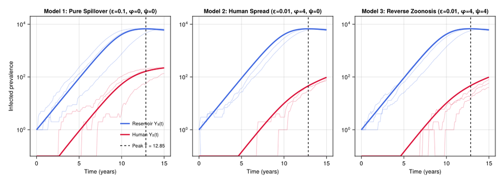

```julia
fig = Figure(size = (1050, 380), fontsize = 12)
rng = StableRNG(2026)

for (col, (title_str, zp)) in enumerate(models)
    ode_res = solve_forward_epidemic(zp; tmax = 15.0, dt = 0.05)
    df = ode_res.df

    ax = Axis(fig[1, col];
        title = title_str,
        xlabel = "Time (years)",
        ylabel = col == 1 ? "Infected prevalence" : "",
        yscale = log10
    )

    # Overlay 3 stochastic Gillespie SSA realizations from JumpProcesses.jl
    for rep in 1:3
        stoch = simulate_stochastic_trajectory(zp; tspan = (0.0, 15.0), rng = rng)
        sp = stoch.bundle.species
        t_grid = range(0.0, 15.0; length = 150)
        y1_s = [max(0.1, Float64(stoch.sol(tg; idxs = sp.Y1))) for tg in t_grid]
        y2_s = [max(0.1, Float64(stoch.sol(tg; idxs = sp.Y2))) for tg in t_grid]
        lines!(ax, collect(t_grid), y1_s; color = (:royalblue, 0.30), linewidth = 1.0)
        lines!(ax, collect(t_grid), y2_s; color = (:crimson, 0.30), linewidth = 1.0)
    end

    # Deterministic ODE curves
    lines!(ax, df.time, max.(df.Y1, 0.1); color = :royalblue, linewidth = 2.6, label = "Reservoir Y₁(t)")
    lines!(ax, df.time, max.(df.Y2, 0.1); color = :crimson, linewidth = 2.6, label = "Human Y₂(t)")
    vlines!(ax, [zp.t_peak]; color = :black, linestyle = :dash, linewidth = 1.4, label = "Peak T = 12.85")
    ylims!(ax, 0.1, 2e4)
    if col == 1
        axislegend(ax; position = :rb, framevisible = false, labelsize = 10)
    end
end
fig
```

## Converting `ReactionSystem` to `ModelFGY` and `TFGY`

Without writing a single differential equation by hand, `ModelFGY(rs, infected, u0, tspan, p)` and `reaction_system_to_fgy(rs, infected, u0, p, tspan)` compile the symbolic reaction rates into the reverse-time $(F(t), G(t), Y(t))$ trajectory required by structured coalescent simulators and likelihood engines:

```julia
bundle = build_zoonosis_reaction_system()
sp = bundle.species
pr = bundle.params
zp3 = model3_params()

u0 = [sp.X1 => zp3.X1_0, sp.Y1 => zp3.Y1_0, sp.X2 => zp3.X2_0, sp.Y2 => zp3.Y2_0]
p  = [pr.nu1 => zp3.nu1, pr.mu1 => zp3.mu1, pr.gamma1 => zp3.gamma1, pr.m1 => zp3.m1,
      pr.beta => zp3.beta, pr.nu2 => zp3.nu2, pr.mu2 => zp3.mu2, pr.gamma2 => zp3.gamma2,
      pr.m2 => zp3.m2, pr.epsilon => zp3.epsilon, pr.phi => zp3.phi, pr.psi => zp3.psi]

tfgy = reaction_system_to_fgy(bundle.rs, [sp.Y1, sp.Y2], u0, p, (0.0, 12.85); res = 200)
println("Demes: ", tfgy.demes)
println("At epidemic peak (t = 12.85, height h = 0):")
println("  Y(T) = ", round.(tfgy.Ys[1], digits = 2))
println("  F(T) = ", round.(tfgy.Fs[1], digits = 2))
```

```
┌ Warning: `SciMLBase.ODEProblem(sys, u0, tspan, p; kw...)` is deprecated. Use
│ `SciMLBase.ODEProblem(sys, merge(Dict(u0), Dict(p)), tspan)` instead.
└ @ ModelingToolkitBase ~/.julia/packages/ModelingToolkitBase/9wONO/src/deprecations.jl:53
Demes: ["Y1", "Y2"]
At epidemic peak (t = 12.85, height h = 0):
  Y(T) = [6733.79, 47.05]
  F(T) = [624.69 6.37; 17.46 17.8]
```